# Caso 12

límite de 3 operarios, plazo mes 18, penalización 10 k€/mes y VAN

# Enunciado

Usted dirige la construcción de una planta cuyo cuadro de prelaciones, duraciones (meses; *a*, *m* y *b* son las estimaciones mínima, más probable y máxima de una distribución triangular y *duration* la duración esperada), operarios por actividad, presupuesto (BAC, k€), duración tope y coste unitario de reducción (CUR, k€ por mes) se adjuntan. La cuadrilla fija es de **3 operarios**. Cuando la planta se entrega, genera un flujo neto de 25 k€ al mes durante 48 meses; la empresa descuenta al 12% anual. El viernes recibe estos mensajes.

Tabla 1: Datos del proyecto

| activity | predecessor | duration | a | m | b | operarios | BAC | cap_duration | ucr |
| --- | --- | --- | --- | --- | --- | --- | --- | --- | --- |
| A | --- | 3 | 1 | 2 | 6 | 3 | 150 | 3 | inf |
| B | --- | 2 | 1 | 2 | 3 | 1 | 100 | 1 | 5.0 |
| C | A,B | 1 | 1 | 1 | 1 | 1 | 150 | 1 | inf |
| D | C | 5 | 3 | 5 | 7 | 2 | 75 | 5 | inf |
| E | D | 6 | 2 | 7 | 9 | 1 | 50 | 4 | 7.0 |
| F | B | 8 | 7 | 8 | 9 | 1 | 75 | 6 | 6.0 |
| G | D | 5 | 2 | 4 | 9 | 1 | 100 | 2 | 5.0 |
| H | E,F,G | 2 | 1 | 2 | 3 | 2 | 125 | 1 | 3.0 |

> **De: Cliente** El contrato fija la entrega en el mes 18 con una penalización de **10 k€ por mes de retraso**. Les pedimos que nos confirmen la probabilidad real de cumplirlo, no la fecha del plan.

> **De: Director financiero** No autorizaré ninguna medida cuyo VAN esperado, neto de penalizaciones y de lo que cueste, no supere al de no hacer nada. Y quiero saber la probabilidad de que el VAN sea negativo en cada opción.

> **De: Jefe de obra** Podemos subcontratar **un operario más** durante todo el proyecto por 3 k€ al mes. Con la cuadrilla actual, por mucho que acorten las actividades, a veces se quedan esperando por falta de gente.

> **De: Contratista** Podemos acelerar actividades con horas extra y refuerzos a los CUR indicados en la tabla (hasta la duración tope). Díganos cuántos meses necesita recortar y le decimos qué actividades.

Responda a las preguntas siguientes **antes** de decidir. En la penúltima se le pide la decisión y cómo la comunicaría a cada uno de los implicados (cliente, director financiero, jefe de obra, contratista).

1. Calcule la duración con las duraciones esperadas sin límite de recursos y con el límite de operarios. ¿Cuál es la cadena crítica con recursos y qué actividades esperan?

2. Simule 3 000 ejecuciones con duraciones triangulares y con el límite de operarios (replanificando en cada réplica) y estime la probabilidad de entregar en el mes 18, el VAN esperado neto de penalización y P(VAN < 0) si no se hace nada.

3. Evalúe cuatro opciones con los mismos números aleatorios: (A) no hacer nada, (B) contratar un operario más, (C) acelerar dos meses con el contratista (reducción con recursos limitados) y (D) las dos cosas a la vez. Tabla de VAN esperado neto, P(VAN < 0), probabilidad de cumplir el plazo, duración media y coste de la aceleración.

4. ¿Qué opción recomienda al director financiero? ¿Y al cliente? ¿Se suman los efectos de B y C en D? Explique por qué.

5. Redacte en tres o cuatro líneas la respuesta a cada implicado.

6. ¿Qué ha cambiado respecto a un análisis determinista con el camino crítico? Señale al menos tres decisiones que habría tomado mal sin recursos, sin incertidumbre o sin VAN.

# Resolución

## Apartado 1

1. Calcule la duración con las duraciones esperadas sin límite de recursos y con el límite de operarios. ¿Cuál es la cadena crítica con recursos y qué actividades esperan?

Cálculo de los tiempos mínimos y máximos de los nodos del grafo Roy paso a paso. El primer paso muestra el grafo resuelto; a partir del siguiente se calcula desde el principio (avance con los botones):

[figure not shown]

paso 0 de 22

[figure not shown]

Figura 1: Grafo Roy con las duraciones esperadas y el camino crítico (sin límite de operarios)

Tabla 2: Calendario sin límite de recursos (meses)

[figure not shown]

ninguna celda (0 de 64)

[figure not shown]

Haz clic en un número de la tabla para ver cómo se calcula.

👆 **Interactivo:** haz clic en cualquier celda de la tabla para ver cómo se calcula (otro clic la deselecciona), o usa los botones y las flechas del teclado.

| Actividad | Duración | Inicio más temprano | Fin más temprano | Inicio más tardío | Fin más tardío | H total | H libre | H independiente |
| --- | --- | --- | --- | --- | --- | --- | --- | --- |
| A | 3 | 0 | 3 | 0 | 3 | 0 | 0 | 0 |
| B | 2 | 0 | 2 | 1 | 3 | 1 | 0 | 0 |
| C | 1 | 3 | 4 | 3 | 4 | 0 | 0 | 0 |
| D | 5 | 4 | 9 | 4 | 9 | 0 | 0 | 0 |
| E | 6 | 9 | 15 | 9 | 15 | 0 | 0 | 0 |
| F | 8 | 2 | 10 | 7 | 15 | 5 | 5 | 4 |
| G | 5 | 9 | 14 | 10 | 15 | 1 | 1 | 1 |
| H | 2 | 15 | 17 | 15 | 17 | 0 | 0 | 0 |

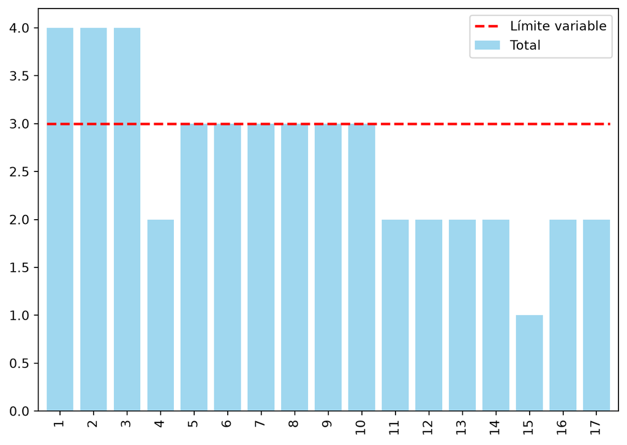

Figura 2: Carga de operarios con los inicios más tempranos frente al límite

El algoritmo de asignación recorre los meses: cada actividad disponible (predecesoras terminadas) empieza, por orden de prioridad (menor inicio más tardío), si caben sus operarios durante toda su duración; si no, espera. Traza mes a mes y Gantt resultante (filas 💤: esperas):

Periodo 1. Empiezan: [‘A’]. Esperan: [‘B (operarios)’]

Periodo 2. Empiezan: []. Esperan: [‘B (operarios)’]

Periodo 3. Empiezan: []. Esperan: [‘B (operarios)’]

Periodo 4. Empiezan: [‘B’]. Esperan: []

Periodo 6. Empiezan: [‘C’, ‘F’]. Esperan: []

Periodo 7. Empiezan: [‘D’]. Esperan: []

Periodo 12. Empiezan: [‘E’, ‘G’]. Esperan: []

Periodo 18. Empiezan: [‘H’]. Esperan: []

[figure not shown]

Figura 3: Gantt con el límite de operarios y las duraciones esperadas

Tabla 3: Inicio de cada actividad sin y con límite

|  | A | B | C | D | E | F | G | H |
| --- | --- | --- | --- | --- | --- | --- | --- | --- |
| inicio sin límite | 0 | 0 | 3 | 4 | 9 | 2 | 9 | 15 |
| inicio con límite | 0 | 3 | 5 | 6 | 11 | 5 | 11 | 17 |
| fin con límite | 3 | 5 | 6 | 11 | 17 | 13 | 16 | 19 |
| espera (meses) | 0 | 3 | 0 | 0 | 0 | 0 | 0 | 0 |

|  | de | a | motivo (precedencia o recurso) |
| --- | --- | --- | --- |
| 0 | A | B | recurso |
| 1 | B | C | precedencia |
| 2 | C | D | precedencia |
| 3 | D | E | precedencia |
| 4 | E | H | precedencia |

**Respuesta:** sin límite de operarios el proyecto dura A–C–D–E–H = 3 + 1 + 5 + 6 + 2 = 17 meses; con 3 operarios dura **19 meses** (2 más). La cadena crítica con recursos (las actividades que fijan esa duración, encadenadas por precedencias o porque una espera a que otra libere operarios: arcos «recurso» de la tabla) es A–B–C–D–E–H. Esperan por falta de operarios: B (3 meses).

## Apartado 2

2. Simule 3 000 ejecuciones con duraciones triangulares y con el límite de operarios (replanificando en cada réplica) y estime la probabilidad de entregar en el mes 18, el VAN esperado neto de penalización y P(VAN < 0) si no se hace nada.

En cada una de las 3000 réplicas se sortean las duraciones (triangulares, redondeadas a meses enteros), se replanifica con 3 operarios y se obtiene la duración τ. El VAN de la réplica descuenta, a la tasa mensual equivalente (1 + k_m)¹² = 1 + 0.12, los costes (el BAC de cada actividad repartido uniformemente en su duración) y el flujo de 25 k€/mes durante 48 meses desde el mes τ; al VAN se le resta la penalización, 10 × máx(0, τ − 18) (sin descontar, como aproximación). Contando las réplicas:

**Respuesta:** si no se hace nada, P(τ ≤ 18) = **0.303** (duración media 19.52 meses), VAN esperado neto de penalización = **23.4 k€** y P(VAN < 0) = **0.185**.

## Apartado 3

3. Evalúe cuatro opciones con los mismos números aleatorios: (A) no hacer nada, (B) contratar un operario más, (C) acelerar dos meses con el contratista (reducción con recursos limitados) y (D) las dos cosas a la vez. Tabla de VAN esperado neto, P(VAN < 0), probabilidad de cumplir el plazo, duración media y coste de la aceleración.

Las reducciones de C y D se calculan con `crashing_recursos`: en cada paso se programa con el límite, se halla la cadena crítica con recursos, se prueban como candidatos sus actividades reducibles (sueltas, por parejas y el corte de coste mínimo) replanificando con cada uno, y se elige el más barato que de verdad acorta el proyecto replanificado. Paso a paso, con el límite actual (C) y con un operario más (D):

Tabla 4: Crashing con recursos para la opción C (límite actual)

| paso | cadena_critica | ackoff_sin_recursos | candidatos_evaluados | actividades | coste_paso | coste_acumulado | duracion_antes | duracion_despues |
| --- | --- | --- | --- | --- | --- | --- | --- | --- |
| 1 | A, B, C, D, E, H | H | 6 | H | 3.0 | 3.0 | 19 | 18 |
| 2 | A, B, C, D, E, H | E | 3 | B | 5.0 | 8.0 | 18 | 17 |

Tabla 5: Crashing con recursos para la opción D (un operario más)

| paso | cadena_critica | ackoff_sin_recursos | candidatos_evaluados | actividades | coste_paso | coste_acumulado | duracion_antes | duracion_despues |
| --- | --- | --- | --- | --- | --- | --- | --- | --- |
| 1 | A, C, D, E, H | H | 3 | H | 3.0 | 3.0 | 17 | 16 |
| 2 | A, C, D, E, H | E | 1 | E | 7.0 | 10.0 | 16 | 15 |

|  | VAN esperado neto (k€) | P(VAN < 0) | P(τ ≤ 18) | duración media (meses) | coste de la aceleración (k€) |
| --- | --- | --- | --- | --- | --- |
| A: no hacer nada | 23.447 | 0.185 | 0.303 | 19.521 | 0.0 |
| B: un operario más | -15.852 | 0.745 | 0.689 | 17.614 | 0.0 |
| C: acelerar dos meses | 32.767 | 0.076 | 0.603 | 18.026 | 8.0 |
| D: operario más y acelerar | -7.677 | 0.642 | 0.878 | 16.268 | 10.0 |

| activity | B | E | H |
| --- | --- | --- | --- |
| C: reducciones | 1 | 0 | 1 |
| D: reducciones | 0 | 1 | 1 |

Coste de la aceleración (Σ CUR × meses recortados): C, 5·1 + 3·1 = 8 k€; D, 7·1 + 3·1 = 10 k€. Opción C: en el paso 2 Ackoff sin recursos habría acortado E, pero con el límite de operarios eso no acorta el proyecto replanificado y se acorta B. Opción D: cada paso acorta lo mismo que Ackoff sin recursos. El coste de la aceleración se suma al BAC de las actividades acortadas y el del operario extra (3 k€/mes × τ, sin descontar) se resta del VAN, junto con la penalización.

**Respuesta:** la tabla de opciones anterior da, para cada una, el VAN esperado neto, P(VAN < 0), la probabilidad de cumplir el plazo, la duración media y el coste de la aceleración; se comparan en el apartado siguiente.

## Apartado 4

4. ¿Qué opción recomienda al director financiero? ¿Y al cliente? ¿Se suman los efectos de B y C en D? Explique por qué.

Cambio de cada opción respecto a A (no hacer nada): VAN esperado neto B -39.3, C +9.3, D -31.1 k€; probabilidad de cumplir el plazo B +0.386, C +0.300, D +0.575.

**Respuesta:**

- Al director financiero: **C: acelerar dos meses**, la de mayor VAN esperado neto (32.8 k€ frente a 23.4 sin hacer nada; P(VAN < 0) = 0.076). Superan a no hacer nada: C: acelerar dos meses.

- Al cliente, que pregunta por la probabilidad de cumplir: con la opción recomendada es 0.60; la más alta la da D: operario más y acelerar (0.88), pero cuesta 40.4 k€ de VAN esperado.

- ¿Se suman B y C en D? B + C = (-39.3) + (+9.3) = -30.0 k€ frente a D = -31.1 k€: no: juntas valen menos que la suma por separado, porque las dos medidas atacan el mismo problema (la duración con recursos): una vez que el operario extra elimina esperas, acelerar recorta menos meses útiles, y el coste de cada medida sí se paga entero.

## Apartado 5

5. Redacte en tres o cuatro líneas la respuesta a cada implicado.

- *Cliente:* «Con la cuadrilla actual la probabilidad de entregar en el mes 18 es de 30% (duración media 19.5 meses). Con las medidas que vamos a tomar sube al 60%, con una duración media de 18.0 meses. Les informaremos cada mes de cómo evoluciona.»

- *Director financiero:* «Propongo acelerar dos meses: VAN esperado neto de penalizaciones y costes 32.8 k€, frente a 23.4 sin hacer nada; probabilidad de VAN negativo 7.6% (sin hacer nada, 18.5%). Adjunto la tabla de las cuatro opciones.»

- *Jefe de obra:* «De momento no contratamos el operario adicional: con 3 k€/mes, en la simulación no compensa (opción B: -15.9 k€ frente a 32.8). Vigilemos las esperas de la cadena crítica.»

- *Contratista:* «Necesitamos acortar B (1 mes) y H (1 mes), con un coste de 8 k€ a los CUR de la tabla.»

## Apartado 6

6. ¿Qué ha cambiado respecto a un análisis determinista con el camino crítico? Señale al menos tres decisiones que habría tomado mal sin recursos, sin incertidumbre o sin VAN.

- **Sin recursos** se habría dicho que el proyecto dura 17 meses y que el plazo del mes 18 se cumple; con 3 operarios dura 19, y sin hacer nada sólo se cumple el 30% de las veces.

- **Sin recursos**, Ackoff habría acortado H y E; con el límite de operarios lo que de verdad acorta es H y B: se habría pagado una reducción que no adelanta la entrega.

- **Sin incertidumbre** se habría prometido una fecha, no una probabilidad: la duración media simulada sin hacer nada es 19.52 meses (con duraciones esperadas, 19) y P(τ ≤ 18) = 0.30.

- **Sin VAN** se habría elegido la opción que más acorta (D: operario más y acelerar) y no la que más valor crea (C: acelerar dos meses); y juzgando cada medida por separado no se ve que B + C (-30.0 k€) no es D (-31.1 k€).